# Introduction

We have been using Spotify the past year to listen to our favorite music and explore new artists who I'd never come across if it wasn't for their recommendation system. Spotify is one of the top music streaming apps of our generation with a library of millions of songs and playlists. Recently, we found out that the app classifies all its tracks according to a system of audio features, and that it stores them in a database easily accessible through its API. So we though, if we could use this data to get a better understanding of what makes a song popular and make predictions of what the next biggest hit requires in order to have a chance at standing at the top. For our tutorial, we will be exploring the relationship between popular music and features that Spotify's API has in order to discover any trends based on subgroups of music divided on things like popularity or year it has been released.

Let's take a look at the most popular songs from 2010 to 2019 and see if we can find any trends that can help us make accurate predictions about the future of music.

According to the Spotify website, all of their songs are given a score in each of the features and characteristics of a song like their:

- Loudness
- Speechiness
- Danceability
- Valence
- Energy
- Tempo
- Instrumentalness
- Liveness
- Acousticness

All of these features will be described in depth later in this process.

The data that we are using comes from this Kaggle dataset: https://www.kaggle.com/datasets/leonardopena/top-spotify-songs-from-20102019-by-year

Goal: Predict what's popular music in the next decade based on top music from 2010-2019

```python
from google.colab import drive
import numpy as np
import pandas as pd
import seaborn as sns
from scipy import stats
import matplotlib.pyplot as plt
from sklearn.model_selection import train_test_split
from statistics import mean
from sklearn.linear_model import LinearRegression
from sklearn.linear_model import LogisticRegression
import statsmodels.api as sm
from statsmodels.formula.api import ols
import pandas.util.testing as tm
from sklearn import model_selection
from sklearn.neighbors import KNeighborsClassifier
from sklearn import metrics
```

```python
drive.mount('/content/gdrive')
```

# Data Collection

Here we collected a dataset of the top songs throughout 2010-2019, obtained from Kaggle.

```python
data = pd.read_csv('gdrive/My Drive/cmsc320Final/top10s.csv', encoding="ISO-8859-1")
data
```

|  | Unnamed: 0 | title | artist | top genre | year | bpm | nrgy | dnce | dB | live | val | dur | acous | spch | pop |
| --- | --- | --- | --- | --- | --- | --- | --- | --- | --- | --- | --- | --- | --- | --- | --- |
| 0 | 1 | Hey, Soul Sister | Train | neo mellow | 2010 | 97 | 89 | 67 | -4 | 8 | 80 | 217 | 19 | 4 | 83 |
| 1 | 2 | Love The Way You Lie | Eminem | detroit hip hop | 2010 | 87 | 93 | 75 | -5 | 52 | 64 | 263 | 24 | 23 | 82 |
| 2 | 3 | TiK ToK | Kesha | dance pop | 2010 | 120 | 84 | 76 | -3 | 29 | 71 | 200 | 10 | 14 | 80 |
| 3 | 4 | Bad Romance | Lady Gaga | dance pop | 2010 | 119 | 92 | 70 | -4 | 8 | 71 | 295 | 0 | 4 | 79 |
| 4 | 5 | Just the Way You Are | Bruno Mars | pop | 2010 | 109 | 84 | 64 | -5 | 9 | 43 | 221 | 2 | 4 | 78 |
| ... | ... | ... | ... | ... | ... | ... | ... | ... | ... | ... | ... | ... | ... | ... | ... |
| 598 | 599 | Find U Again (feat. Camila Cabello) | Mark Ronson | dance pop | 2019 | 104 | 66 | 61 | -7 | 20 | 16 | 176 | 1 | 3 | 75 |
| 599 | 600 | Cross Me (feat. Chance the Rapper & PnB Rock) | Ed Sheeran | pop | 2019 | 95 | 79 | 75 | -6 | 7 | 61 | 206 | 21 | 12 | 75 |
| 600 | 601 | No Brainer (feat. Justin Bieber, Chance the Ra... | DJ Khaled | dance pop | 2019 | 136 | 76 | 53 | -5 | 9 | 65 | 260 | 7 | 34 | 70 |
| 601 | 602 | Nothing Breaks Like a Heart (feat. Miley Cyrus) | Mark Ronson | dance pop | 2019 | 114 | 79 | 60 | -6 | 42 | 24 | 217 | 1 | 7 | 69 |
| 602 | 603 | Kills You Slowly | The Chainsmokers | electropop | 2019 | 150 | 44 | 70 | -9 | 13 | 23 | 213 | 6 | 6 | 67 |

603 rows × 15 columns

Goal: Predict what's popular music in the next decade based on top music from 2010-2019

Data Science Pipeline

- Data Collection (Based on a dataset that we found)
- Data processing (Not much filtering/cleaning the dataset)
- Exploratory analyis & data visualization ()
- Analysis, hypothesis testing, ml
- Insight & policy decision

**Data Processing**

There is some unnecessary repeat of the index, so let's scrap that.

```python
data = data.drop('Unnamed: 0', axis = 1)
data
```

|  | title | artist | top genre | year | bpm | nrgy | dnce | dB | live | val | dur | acous | spch | pop |
| --- | --- | --- | --- | --- | --- | --- | --- | --- | --- | --- | --- | --- | --- | --- |
| 0 | Hey, Soul Sister | Train | neo mellow | 2010 | 97 | 89 | 67 | -4 | 8 | 80 | 217 | 19 | 4 | 83 |
| 1 | Love The Way You Lie | Eminem | detroit hip hop | 2010 | 87 | 93 | 75 | -5 | 52 | 64 | 263 | 24 | 23 | 82 |
| 2 | TiK ToK | Kesha | dance pop | 2010 | 120 | 84 | 76 | -3 | 29 | 71 | 200 | 10 | 14 | 80 |
| 3 | Bad Romance | Lady Gaga | dance pop | 2010 | 119 | 92 | 70 | -4 | 8 | 71 | 295 | 0 | 4 | 79 |
| 4 | Just the Way You Are | Bruno Mars | pop | 2010 | 109 | 84 | 64 | -5 | 9 | 43 | 221 | 2 | 4 | 78 |
| ... | ... | ... | ... | ... | ... | ... | ... | ... | ... | ... | ... | ... | ... | ... |
| 598 | Find U Again (feat. Camila Cabello) | Mark Ronson | dance pop | 2019 | 104 | 66 | 61 | -7 | 20 | 16 | 176 | 1 | 3 | 75 |
| 599 | Cross Me (feat. Chance the Rapper & PnB Rock) | Ed Sheeran | pop | 2019 | 95 | 79 | 75 | -6 | 7 | 61 | 206 | 21 | 12 | 75 |
| 600 | No Brainer (feat. Justin Bieber, Chance the Ra... | DJ Khaled | dance pop | 2019 | 136 | 76 | 53 | -5 | 9 | 65 | 260 | 7 | 34 | 70 |
| 601 | Nothing Breaks Like a Heart (feat. Miley Cyrus) | Mark Ronson | dance pop | 2019 | 114 | 79 | 60 | -6 | 42 | 24 | 217 | 1 | 7 | 69 |
| 602 | Kills You Slowly | The Chainsmokers | electropop | 2019 | 150 | 44 | 70 | -9 | 13 | 23 | 213 | 6 | 6 | 67 |

603 rows × 14 columns

We will also be dropping the title column, because we are doing any analysis with regards to title and music popularity. Some potential variables obviously could've been considered with it such as word frequency and title length, but there are other direct variables and more specific attributes that are provided to us in the dataset, so it will not be necessary.

```python
data = data.drop('title', axis = 1)
data
```

|  | artist | top genre | year | bpm | nrgy | dnce | dB | live | val | dur | acous | spch | pop |
| --- | --- | --- | --- | --- | --- | --- | --- | --- | --- | --- | --- | --- | --- |
| 0 | Train | neo mellow | 2010 | 97 | 89 | 67 | -4 | 8 | 80 | 217 | 19 | 4 | 83 |
| 1 | Eminem | detroit hip hop | 2010 | 87 | 93 | 75 | -5 | 52 | 64 | 263 | 24 | 23 | 82 |
| 2 | Kesha | dance pop | 2010 | 120 | 84 | 76 | -3 | 29 | 71 | 200 | 10 | 14 | 80 |
| 3 | Lady Gaga | dance pop | 2010 | 119 | 92 | 70 | -4 | 8 | 71 | 295 | 0 | 4 | 79 |
| 4 | Bruno Mars | pop | 2010 | 109 | 84 | 64 | -5 | 9 | 43 | 221 | 2 | 4 | 78 |
| ... | ... | ... | ... | ... | ... | ... | ... | ... | ... | ... | ... | ... | ... |
| 598 | Mark Ronson | dance pop | 2019 | 104 | 66 | 61 | -7 | 20 | 16 | 176 | 1 | 3 | 75 |
| 599 | Ed Sheeran | pop | 2019 | 95 | 79 | 75 | -6 | 7 | 61 | 206 | 21 | 12 | 75 |
| 600 | DJ Khaled | dance pop | 2019 | 136 | 76 | 53 | -5 | 9 | 65 | 260 | 7 | 34 | 70 |
| 601 | Mark Ronson | dance pop | 2019 | 114 | 79 | 60 | -6 | 42 | 24 | 217 | 1 | 7 | 69 |
| 602 | The Chainsmokers | electropop | 2019 | 150 | 44 | 70 | -9 | 13 | 23 | 213 | 6 | 6 | 67 |

603 rows × 13 columns

During the exploratory analysis, we will be looking at genres. Let's have a look at the list of music genres from the dataset that we have to work with.

```python
data.groupby('top genre')['top genre'].count()
```

```
top genre
acoustic pop                   2
alaska indie                   1
alternative r&b                1
art pop                        8
atl hip hop                    5
australian dance               6
australian hip hop             1
australian pop                 5
barbadian pop                 15
baroque pop                    2
belgian edm                    2
big room                      10
boy band                      15
british soul                  11
brostep                        2
canadian contemporary r&b      9
canadian hip hop               2
canadian latin                 1
canadian pop                  34
candy pop                      2
celtic rock                    1
chicago rap                    1
colombian pop                  3
complextro                     6
contemporary country           1
dance pop                    327
danish pop                     1
detroit hip hop                2
downtempo                      2
edm                            5
electro                        2
electro house                  1
electronic trap                2
electropop                    13
escape room                    2
folk-pop                       2
french indie pop               1
hip hop                        4
hip pop                        6
hollywood                      1
house                          1
indie pop                      2
irish singer-songwriter        1
latin                          4
metropopolis                   1
moroccan pop                   1
neo mellow                     9
permanent wave                 4
pop                           60
tropical house                 3
Name: top genre, dtype: int64
```

This data by genre seems to be a little messy, with many variables overlapping each other. To help organize a little bit, I can notice that a lot of the music genres have a common factor such as "pop", "australian pop", or "dance pop", all being forms of pop music. With that, let's do some cleaning.

Pop and Hip-Hop seem to have a lot of subcategories without overlap (ex: Hip pop or pop hip-hop), so we will merge those into the "Pop" and "Hip-Hop" columns

```python
data_temp = data

data_temp.loc[data['top genre'].str.contains("pop"),'top genre'] = 'pop'
data_temp.loc[data['top genre'].str.contains("hip hop"),'top genre'] = 'hip hop'

data.groupby('top genre')['top genre'].count()
```

```
top genre
alaska indie                   1
alternative r&b                1
australian dance               6
belgian edm                    2
big room                      10
boy band                      15
british soul                  11
brostep                        2
canadian contemporary r&b      9
canadian latin                 1
celtic rock                    1
chicago rap                    1
complextro                     6
contemporary country           1
downtempo                      2
edm                            5
electro                        2
electro house                  1
electronic trap                2
escape room                    2
hip hop                       14
hollywood                      1
house                          1
irish singer-songwriter        1
latin                          4
neo mellow                     9
permanent wave                 4
pop                          485
tropical house                 3
Name: top genre, dtype: int64
```

Much more condensed! The genres are a lot simpler to differentiate, given that there are less and more clearly distinct ones to work with.

# Exploratory Analysis and Data Visualization

Our first idea was to group each genre and determine it's popularity based on artists, hopefully witnessing any consistency in music genres per year, or ones that notably fluctuate. This can allow us to explore if there are any frequent genres that help indicate if they are able to factor into how we predict which genres will remain popular in the upcoming years.

```python
years = data['year']
years = years.drop_duplicates().reset_index(drop = True)
#Setting the years in an array so that we can iterate through them

years
```

```
0    2010
1    2011
2    2012
3    2013
4    2014
5    2015
6    2016
7    2017
8    2018
9    2019
Name: year, dtype: int64
```

```python
genres = data_temp.groupby('top genre')['pop'].mean().reset_index()
genres
```

|  | top genre | pop |
| --- | --- | --- |
| 0 | alaska indie | 36.000000 |
| 1 | alternative r&b | 84.000000 |
| 2 | australian dance | 62.333333 |
| 3 | belgian edm | 60.000000 |
| 4 | big room | 65.600000 |
| 5 | boy band | 69.666667 |
| 6 | british soul | 62.181818 |
| 7 | brostep | 86.000000 |
| 8 | canadian contemporary r&b | 77.666667 |
| 9 | canadian latin | 18.000000 |
| 10 | celtic rock | 80.000000 |
| 11 | chicago rap | 73.000000 |
| 12 | complextro | 67.333333 |
| 13 | contemporary country | 76.000000 |
| 14 | downtempo | 61.500000 |
| 15 | edm | 78.200000 |
| 16 | electro | 74.500000 |
| 17 | electro house | 70.000000 |
| 18 | electronic trap | 79.500000 |
| 19 | escape room | 90.000000 |
| 20 | hip hop | 63.857143 |
| 21 | hollywood | 37.000000 |
| 22 | house | 72.000000 |
| 23 | irish singer-songwriter | 81.000000 |
| 24 | latin | 62.250000 |
| 25 | neo mellow | 60.000000 |
| 26 | permanent wave | 58.750000 |
| 27 | pop | 66.383505 |
| 28 | tropical house | 71.666667 |

Cool! We now have each genre and their respective means. These, however, are the mean popularities for each genre for all of the years 2010-2019. We will iterate through each year to see how much it varied in popularity per year in the decade.

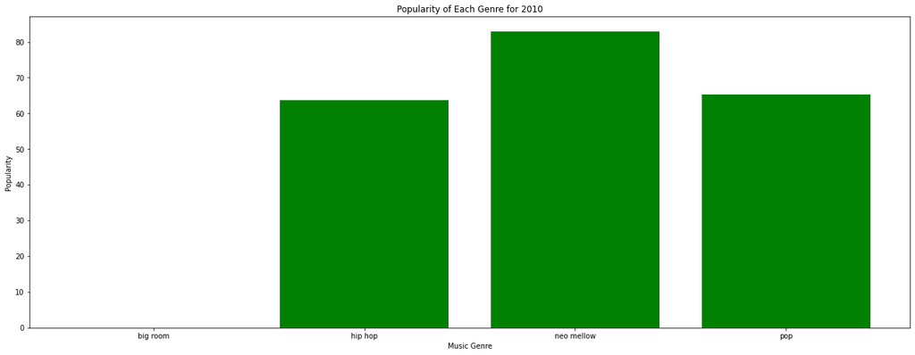

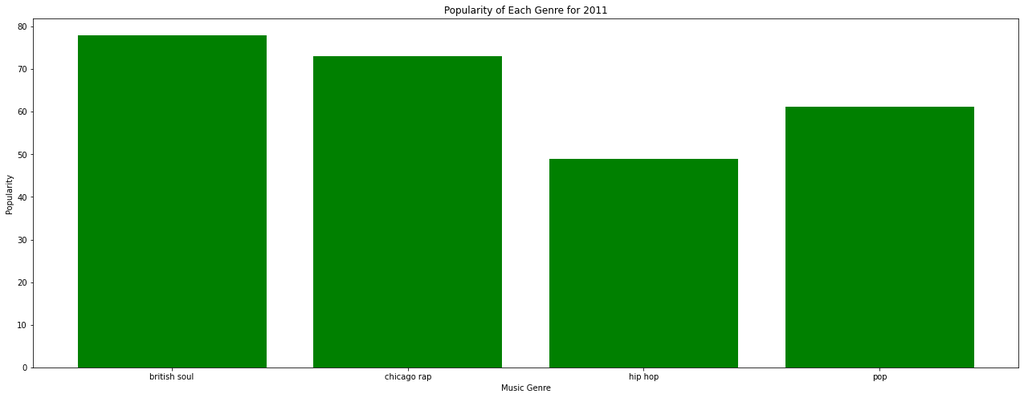

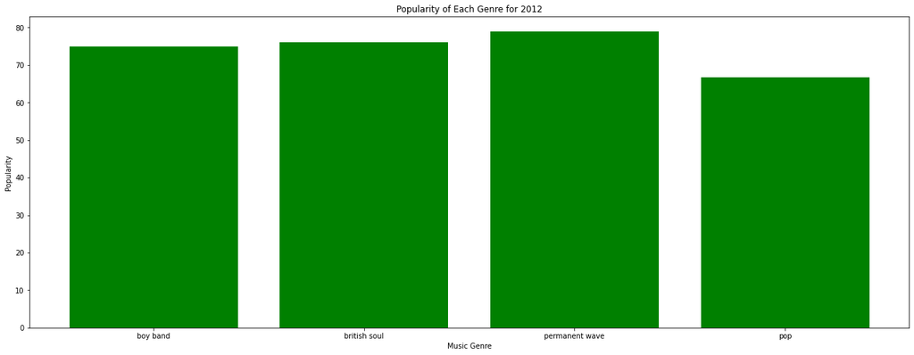

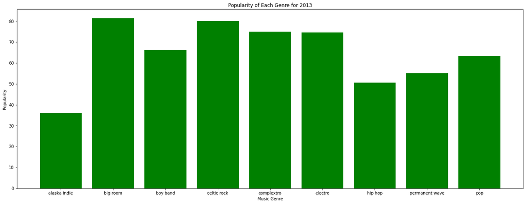

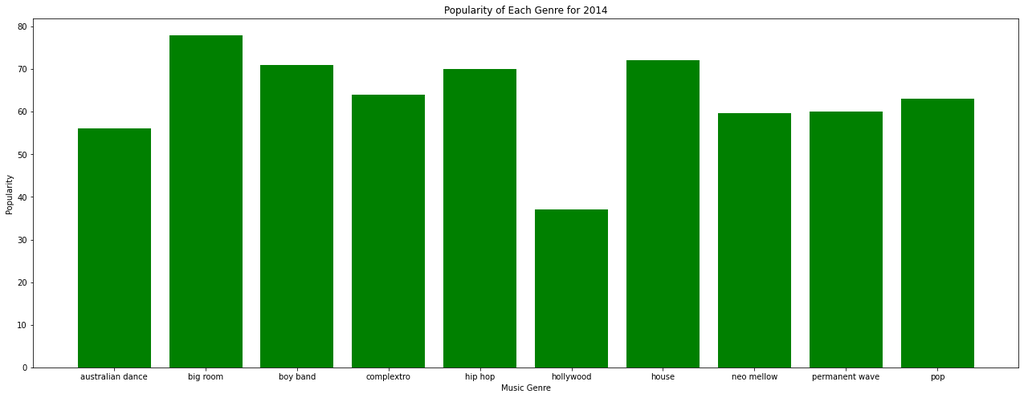

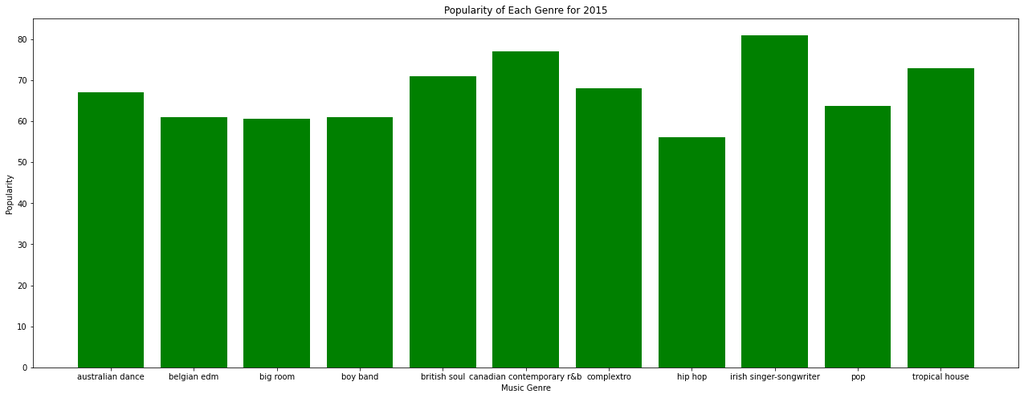

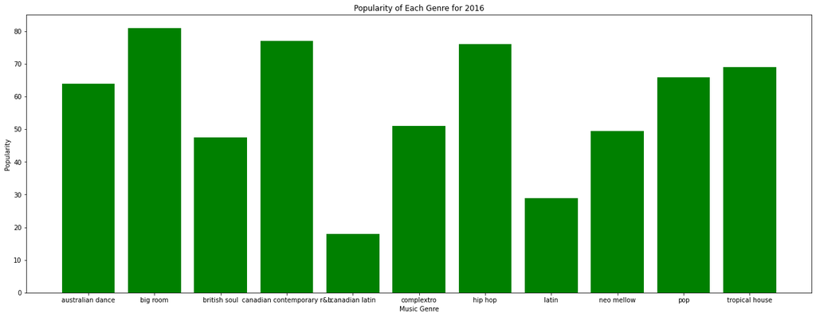

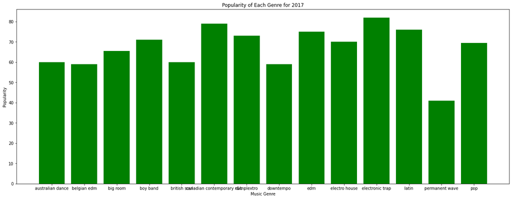

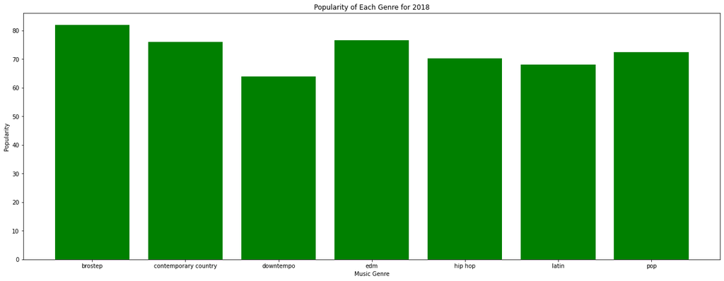

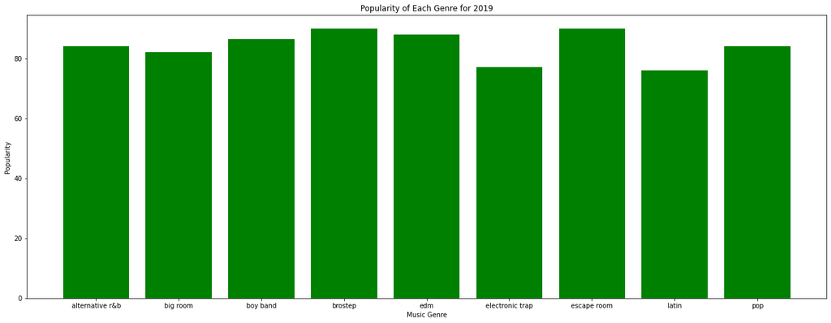

```python
for y in years:
  df_temp2 = data_temp[data_temp['year'] == y]
  df_temp_y = df_temp2.groupby(['top genre'])['pop'].mean()
  df_temp_y = df_temp_y.reset_index()
  plt.figure(figsize=(22, 8))
  plt.bar(df_temp_y["top genre"], df_temp_y["pop"], color = 'green')
  plt.title("Popularity of Each Genre for " +str(y))
  plt.xlabel("Music Genre")
  plt.ylabel("Popularity")
  plt.show()
```

I explained earlier how some genres tend to be associated with specific regions of artists, such as pop from the United States, Latin music from Latin America, or EDM from Europe. Or, to summarize, these are non-American genres. We can narrow down our exploration to artists' origins to see if they, American or non-American, are becoming more popular or not.

```python
year_and_pop = data.drop(['bpm', 'nrgy', 'dnce', 'dB', 'live', 'val', 'dur', 'acous', 'spch'], axis = 1)
artists = year_and_pop.groupby('artist')['pop'].mean()
artists = artists.reset_index()
artists
```

|  | artist | pop |
| --- | --- | --- |
| 0 | 3OH!3 | 62.000000 |
| 1 | 5 Seconds of Summer | 71.000000 |
| 2 | A Great Big World | 61.000000 |
| 3 | Adam Lambert | 62.500000 |
| 4 | Adele | 61.500000 |
| ... | ... | ... |
| 179 | ZAYN | 72.800000 |
| 180 | Zara Larsson | 77.000000 |
| 181 | Zedd | 67.333333 |
| 182 | fun. | 67.500000 |
| 183 | will.i.am | 68.000000 |

184 rows × 2 columns

Oh wow, that's a lot of artists! It might be better to take the top 15 artists from the decade to get a cleaner look when plotting our data. It also could help us see if we see frequent names in our top 15 as the years go by.

```python
top_15_artists = year_and_pop['artist'].value_counts()[:15].index.tolist()
top_15_artists

data_temp = year_and_pop
data_top_15 = data_temp[data_temp['artist'].isin(top_15_artists)]
top_copy = data_top_15


#this will be used to graph popularity per year later on
data_top_15 = data_top_15.groupby(['artist', 'year'])['pop'].mean()
data_top_15 = data_top_15.reset_index()


top_15 = top_copy.groupby(['artist'])['pop'].mean()
top_15 = top_15.reset_index()

top_15
```

|  | artist | pop |
| --- | --- | --- |
| 0 | Adele | 61.500000 |
| 1 | Ariana Grande | 75.777778 |
| 2 | Britney Spears | 55.222222 |
| 3 | Bruno Mars | 72.000000 |
| 4 | Calvin Harris | 78.200000 |
| 5 | Ed Sheeran | 78.363636 |
| 6 | Jennifer Lopez | 55.900000 |
| 7 | Justin Bieber | 71.875000 |
| 8 | Katy Perry | 62.117647 |
| 9 | Lady Gaga | 68.857143 |
| 10 | Maroon 5 | 74.866667 |
| 11 | Pitbull | 58.000000 |
| 12 | Rihanna | 65.400000 |
| 13 | Shawn Mendes | 77.363636 |
| 14 | The Chainsmokers | 76.272727 |

```python
data_top_15['American or Non-American'] = 0

for i, r in data_top_15.iterrows():
  if r['artist'] == 'Adele' or r['artist'] == 'Calvin Harris' \
  or r['artist'] == 'Ed Sheeran' or r['artist'] == 'Shawn Mendes':
    data_top_15.loc[i, 'American or Non-American'] = 'Non-American'
  else:
    data_top_15.loc[i, 'American or Non-American'] = 'American'

top_15_2 = data_top_15.drop_duplicates('artist')
top_15_2 = top_15_2.reset_index(drop=True)
top_15_2
```

|  | artist | year | pop | American or Non-American |
| --- | --- | --- | --- | --- |
| 0 | Adele | 2011 | 78.000000 | Non-American |
| 1 | Ariana Grande | 2013 | 68.000000 | American |
| 2 | Britney Spears | 2010 | 62.000000 | American |
| 3 | Bruno Mars | 2010 | 75.500000 | American |
| 4 | Calvin Harris | 2013 | 73.000000 | Non-American |
| 5 | Ed Sheeran | 2015 | 70.250000 | Non-American |
| 6 | Jennifer Lopez | 2011 | 54.250000 | American |
| 7 | Justin Bieber | 2010 | 77.000000 | American |
| 8 | Katy Perry | 2010 | 62.500000 | American |
| 9 | Lady Gaga | 2010 | 73.666667 | American |
| 10 | Maroon 5 | 2010 | 65.000000 | American |
| 11 | Pitbull | 2011 | 79.000000 | American |
| 12 | Rihanna | 2010 | 65.000000 | American |
| 13 | Shawn Mendes | 2015 | 78.000000 | Non-American |
| 14 | The Chainsmokers | 2014 | 65.000000 | American |

Great! We narrowed it down to a much cleaner top 15. You can easily look up where these artists are from and compare it to their overall average popularity. However, I made a column to make it even easier, classifying each artist from the top 15 as American or non-American based on their home country. We will now do some comparisons for how these artists' average popularity varied throughout the years 2010-2019 by comparing them through bar graphs year by year .

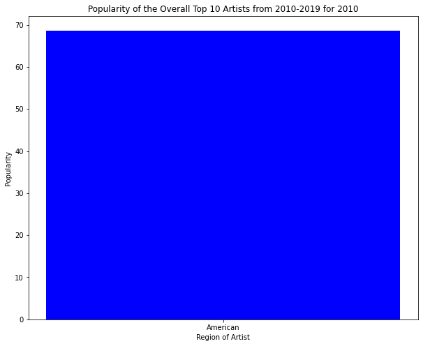

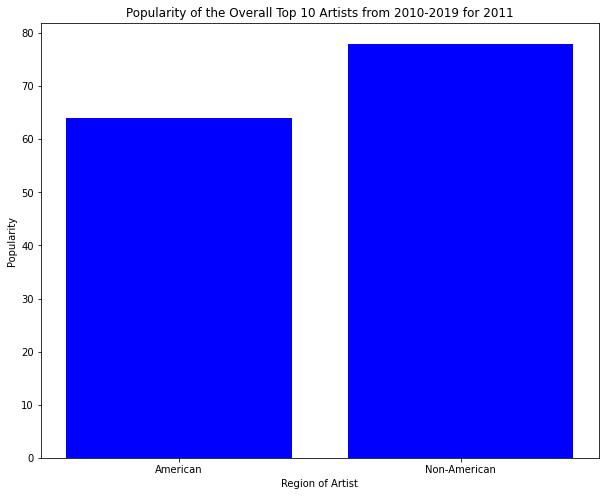

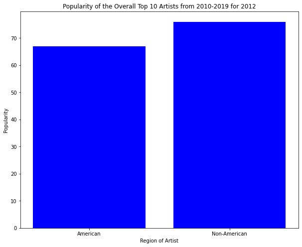

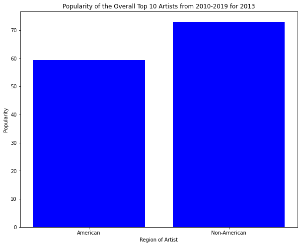

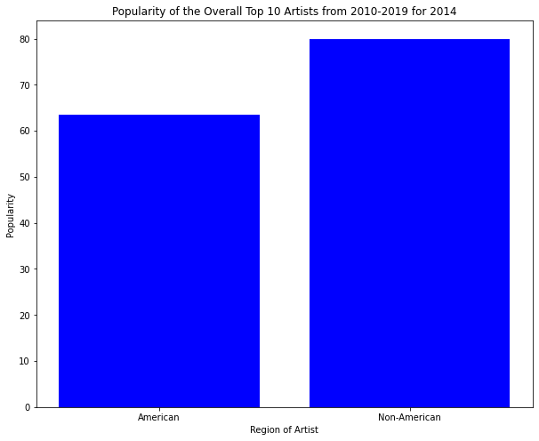

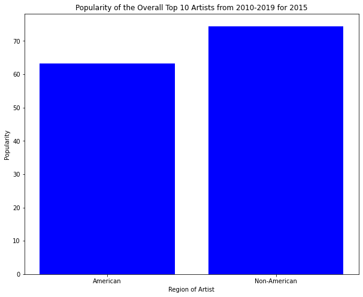

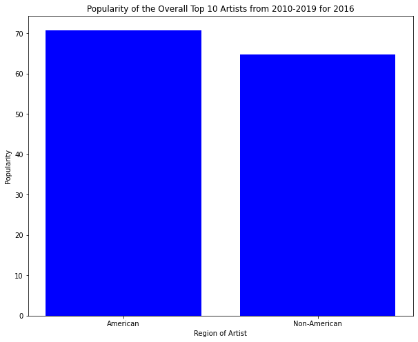

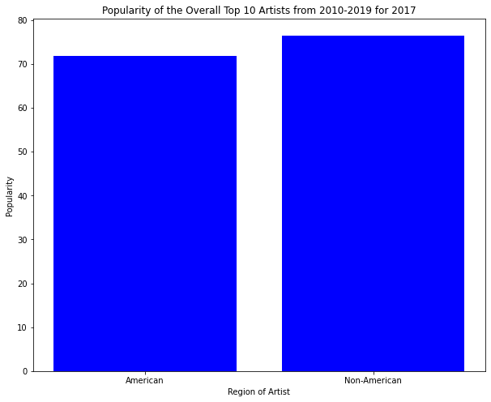

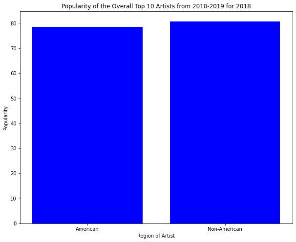

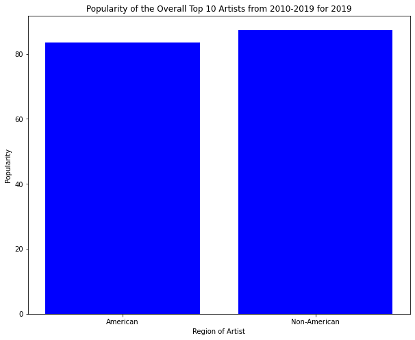

```python
for y in years:
  df_temp2 = data_top_15[data_top_15['year'] == y]
  df_temp_y = df_temp2.groupby(['American or Non-American'])['pop'].mean()
  df_temp_y = df_temp_y.reset_index()
  plt.figure(figsize=(10, 8))
  plt.bar(df_temp_y["American or Non-American"], df_temp_y["pop"], color = 'blue')
  plt.title("Popularity of the Overall Top 10 Artists from 2010-2019 for " +str(y))
  plt.xlabel("Region of Artist")
  plt.ylabel("Popularity")
  plt.show()
```

These observations seem to be a little ambiguous when it comes to determining music popularity trends through the years 2010-2019. There were some outlying details that we did not take into consideration. For example, just because it is a non-American genre, doesn't mean that it was made by a non-American artist. American artists can be diving into other genres to diversify their content or gain popularity, and vice versa. Examples include Beyonce hopping onto a "Mi Gente" remix, or Adele's general pop content, a heavy American genre.

We can avoid ambiguity that was provided in the beginning data exploration with the multiple attributes in our dataset. With these, we can get into more specific analysis to determine and hypothesize the popularity of certain types of music in the future.

We are now looking at these features in the dataset

- Beats per minute (bpm): This describes the estimated tempo of the track in bpm. Tempo is described the speed or pace of a given piece and derives directly from the average beat duration.
- Energy (nrgy): Energy is a measure from 0 to 100 and represents an intuitive measure of the intensity and activity of a track. Typically, energetic tracks feel fast, loud, and noisy like death metal would be classified high energy, while a Bach prelude would have a lower energy rating.
- Danceability (dnce): Danceability describes how suitable a track is for dancing based on a combination of musical elements including tempo, rhythm stability, and beat strength. A value closer to 0 means the track is harder to dance to and a value closer to 100 means the track is easy to dance to.
- Loudness (dB): The overall loudness of a track is measured in decibels (dB) and the values are averaged across the full track which is useful for comparing relative loudness between tracks. Loudness is the feature of a sound that correlates to the physical strength or amplitude. Values typical range between -60 and 0 db
- Liveness (live): Detects the presence of an audience in the recording. Higher liveness values represent an increased probability that the track was performed live. A value above 0.8 provides strong likelihood that the track is live.
- Valence (val): A measure from 0 to 100 describing the musical positiveness conveyed by a track. Tracks with high valence sound more positive (e.g. happy, cheerful), while tracks with low valence sound more negative (e.g. sad, depressed, angry).
- Acousticness (acous): A track is consiedered acoustic when it solely or primarily uses instruments that produce sound through acoustic means, as opposed to electronic means of amplification.

|  | year | bpm | nrgy | dnce | dB | live | val | dur | acous | spch | pop |
| --- | --- | --- | --- | --- | --- | --- | --- | --- | --- | --- | --- |
| year | 1.000000 | -0.104247 | -0.225596 | 0.079269 | -0.126471 | -0.136331 | -0.122025 | -0.215344 | 0.101725 | 0.004778 | 0.241261 |
| bpm | -0.104247 | 1.000000 | 0.126170 | -0.131301 | 0.183870 | 0.081579 | 0.016021 | -0.029359 | -0.113257 | 0.058999 | 0.018983 |
| nrgy | -0.225596 | 0.126170 | 1.000000 | 0.167209 | 0.537528 | 0.186738 | 0.409577 | -0.143610 | -0.562287 | 0.107313 | -0.057645 |
| dnce | 0.079269 | -0.131301 | 0.167209 | 1.000000 | 0.233170 | -0.028801 | 0.501696 | -0.176841 | -0.240064 | -0.028041 | 0.116054 |
| dB | -0.126471 | 0.183870 | 0.537528 | 0.233170 | 1.000000 | 0.081934 | 0.282922 | -0.104723 | -0.190401 | -0.001110 | 0.156897 |
| live | -0.136331 | 0.081579 | 0.186738 | -0.028801 | 0.081934 | 1.000000 | 0.020226 | 0.098339 | -0.098167 | 0.144103 | -0.075749 |
| val | -0.122025 | 0.016021 | 0.409577 | 0.501696 | 0.282922 | 0.020226 | 1.000000 | -0.262256 | -0.249038 | 0.122013 | 0.038953 |
| dur | -0.215344 | -0.029359 | -0.143610 | -0.176841 | -0.104723 | 0.098339 | -0.262256 | 1.000000 | 0.091802 | 0.054564 | -0.104363 |
| acous | 0.101725 | -0.113257 | -0.562287 | -0.240064 | -0.190401 | -0.098167 | -0.249038 | 0.091802 | 1.000000 | 0.002763 | 0.026704 |
| spch | 0.004778 | 0.058999 | 0.107313 | -0.028041 | -0.001110 | 0.144103 | 0.122013 | 0.054564 | 0.002763 | 1.000000 | -0.041490 |
| pop | 0.241261 | 0.018983 | -0.057645 | 0.116054 | 0.156897 | -0.075749 | 0.038953 | -0.104363 | 0.026704 | -0.041490 | 1.000000 |

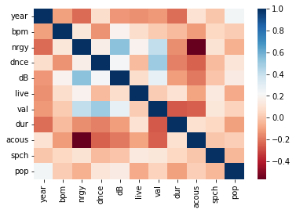

```python
#testing for multicollinearity
# calculate the correlation matrix
corr = data.corr()

# display the correlation matrix
display(corr)

# plot the correlation heatmap
sns.heatmap(corr, xticklabels=corr.columns, yticklabels=corr.columns, cmap='RdBu')

# we can say that we dont have highly correlated exploratory variables
```

Let's now check to see some comparisons that each of our attributes has with popularity

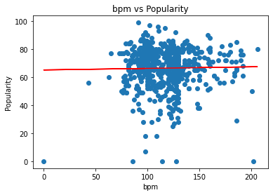

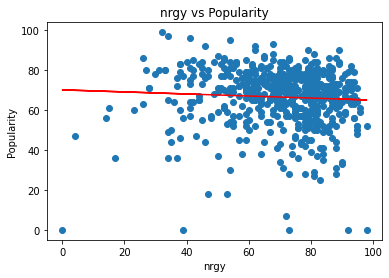

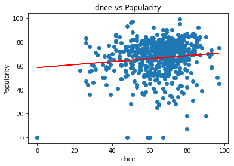

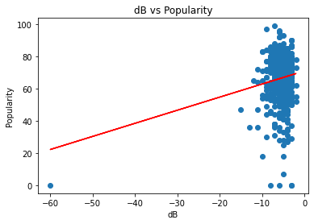

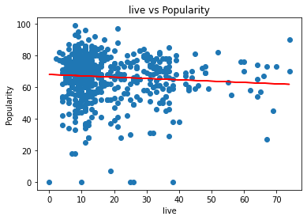

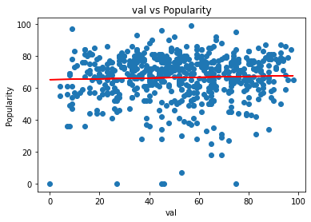

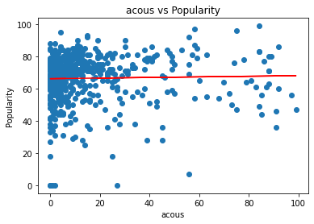

```python
#checking scatterplot between year and features that we are interested in
#indep = data["year"]
col_names = ["bpm","nrgy", "dnce", "dB", "live", "val", "acous"]
dep = data["pop"]
for x in col_names:
    indep = data[x]
    plt.title(x + ' vs Popularity')
    plt.xlabel(x)
    plt.ylabel("Popularity")
    plt.scatter(indep,dep)
    d = np.polyfit(indep, dep, 1)
    f = np.poly1d(d)
    f = f(indep)
    plt.plot(indep, f, color = 'red')
    plt.show()
```

Some definitely more organized plots than others, but not really one stands in regards to a clear correlation between a specific attribute and popularity.

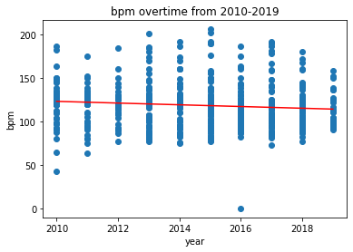

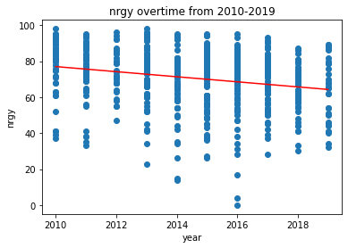

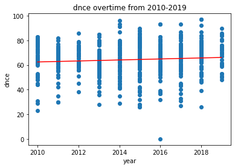

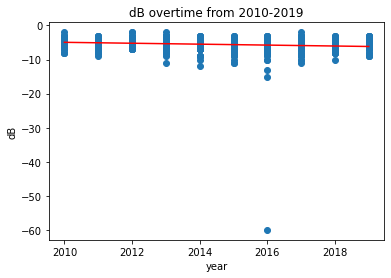

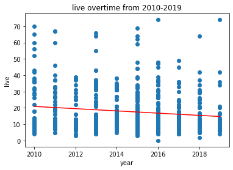

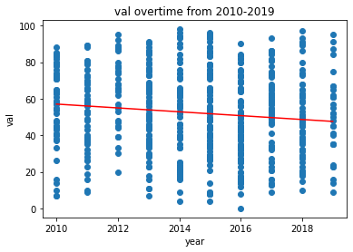

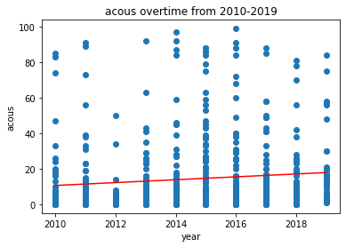

```python
for i in col_names:
  plt.scatter(data['year'], data[i])
  plt.xlabel('year')
  plt.ylabel(i)
  plt.title(i + ' overtime from 2010-2019')
  d = np.polyfit(data['year'], data[i], 1)
  f = np.poly1d(d)
  f = f(data['year'])
  plt.plot(data['year'], f, color = 'red')
  plt.show()
```

```
[Text(0, 0.5, 'bpm'),
```

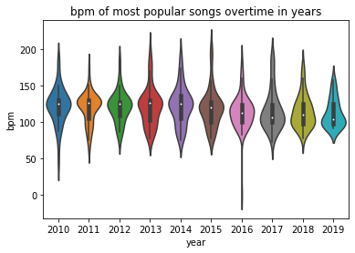

```python
years = []

for i in range(2010, 2020):
  years.append(i)

bpm_plt = sns.violinplot(x = data['year'],y = data['bpm'],scale='width',inner='box')
bpm_plt.set(ylabel = 'bpm', title = 'bpm of most popular songs overtime in years')
```

```
[Text(0, 0.5, 'nrgy'),
```

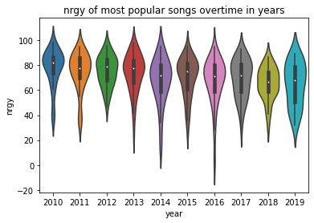

```python
nrgy_plt = sns.violinplot(x = data['year'],y = data['nrgy'],scale='width',inner='box')
nrgy_plt.set(ylabel = 'nrgy', title = 'nrgy of most popular songs overtime in years')
```

```
[Text(0, 0.5, 'dnce'),
```

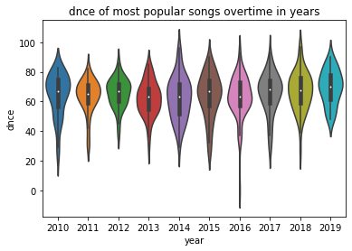

```python
dnce_plt = sns.violinplot(x = data['year'],y = data['dnce'],scale='width',inner='box')
dnce_plt.set(ylabel = 'dnce', title = 'dnce of most popular songs overtime in years')
```

```
[Text(0, 0.5, 'dB'),
```

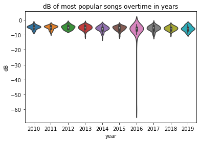

```python
dB_plt = sns.violinplot(x = data['year'],y = data['dB'],scale='width',inner='box')
dB_plt.set(ylabel = 'dB', title = 'dB of most popular songs overtime in years')
```

```
[Text(0, 0.5, 'live'),
```

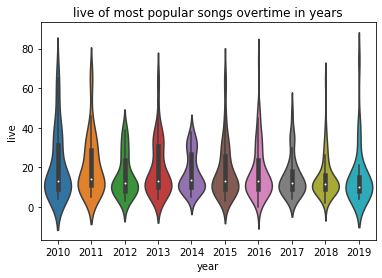

```python
live_plt = sns.violinplot(x = data['year'],y = data['live'],scale='width',inner='box')
live_plt.set(ylabel = 'live', title = 'live of most popular songs overtime in years')
```

```
[Text(0, 0.5, 'val'),
```

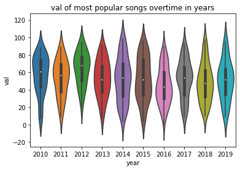

```python
val_plt = sns.violinplot(x = data['year'],y = data['val'],scale='width',inner='box')
val_plt.set(ylabel = 'val', title = 'val of most popular songs overtime in years')
```

```
[Text(0, 0.5, 'acous'),
```

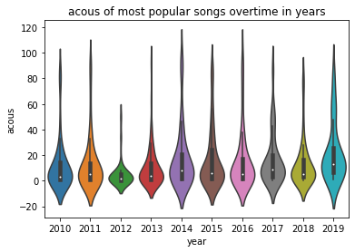

```python
acous_plt = sns.violinplot(x = data['year'],y = data['acous'],scale='width',inner='box')
acous_plt.set(ylabel = 'acous', title = 'acous of most popular songs overtime in years')
```

```python
values = []

avg_data = {'year':years}

for i in col_names:
  values = []
  for y in years:
    year_data = data[data['year'] == y]
    avg = mean(year_data[i])
    values.append(avg)
  avg_data.update({i: values})

avg_data = pd.DataFrame(data=avg_data)
```

```python
avg_data
```

|  | year | bpm | nrgy | dnce | dB | live | val | acous |
| --- | --- | --- | --- | --- | --- | --- | --- | --- |
| 0 | 2010 | 122.058824 | 77.901961 | 64.529412 | -4.901961 | 21.176471 | 57.000000 | 11.627451 |
| 1 | 2011 | 119.075472 | 74.886792 | 63.641509 | -5.018868 | 20.943396 | 53.698113 | 13.339623 |
| 2 | 2012 | 121.085714 | 75.485714 | 65.714286 | -4.857143 | 15.828571 | 64.171429 | 4.857143 |
| 3 | 2013 | 121.676056 | 73.873239 | 62.042254 | -5.140845 | 19.718310 | 53.183099 | 10.323944 |
| 4 | 2014 | 123.000000 | 67.775862 | 62.534483 | -5.775862 | 17.293103 | 52.086207 | 17.551724 |
| 5 | 2015 | 119.768421 | 70.336842 | 63.663158 | -5.621053 | 18.305263 | 52.526316 | 16.600000 |
| 6 | 2016 | 114.325000 | 67.237500 | 63.325000 | -6.712500 | 17.737500 | 45.150000 | 15.875000 |
| 7 | 2017 | 116.800000 | 69.169231 | 65.369231 | -5.615385 | 15.369231 | 52.276923 | 16.600000 |
| 8 | 2018 | 114.593750 | 65.468750 | 67.203125 | -5.671875 | 14.750000 | 48.765625 | 12.781250 |
| 9 | 2019 | 112.451613 | 64.741935 | 69.709677 | -5.774194 | 15.161290 | 50.806452 | 21.741935 |